Eli Lilly and Company

# Reproducible computation at scale in R

[figure not shown]

Will Landau

## Purpose: manage long runtimes

[figure not shown]

## Data analysis workflows can be complicated.

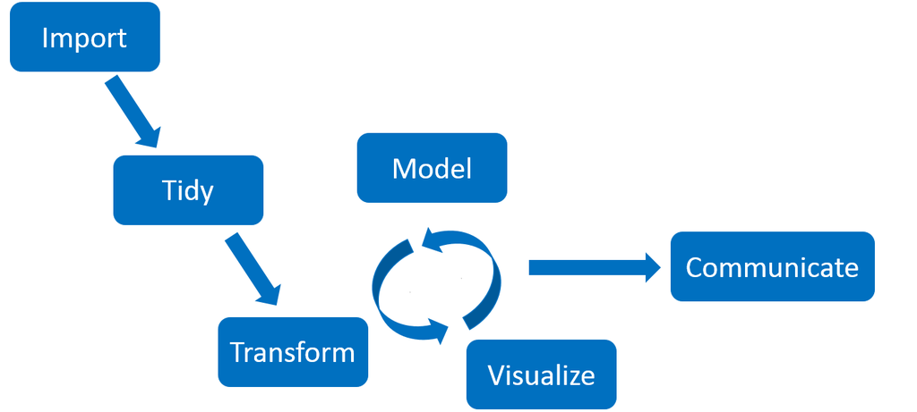

## When you go back and change something…

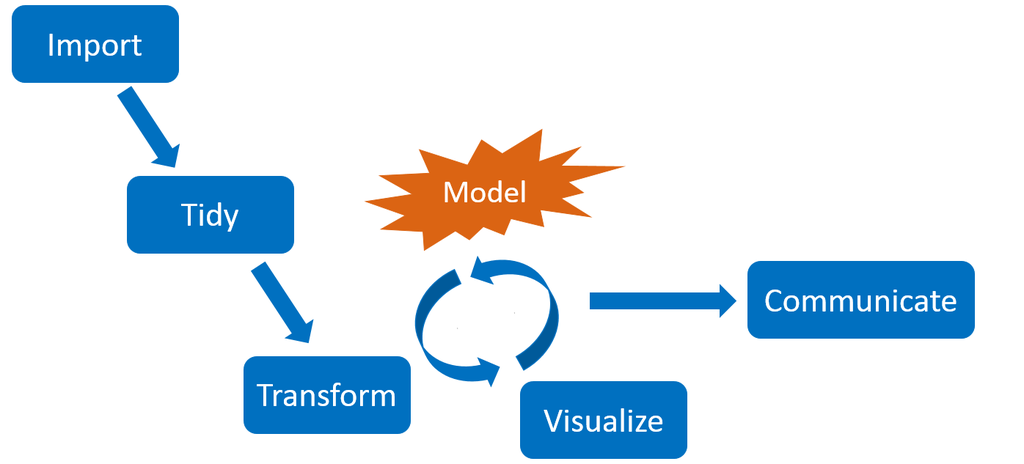

## …everything downstream is **no longer valid**.

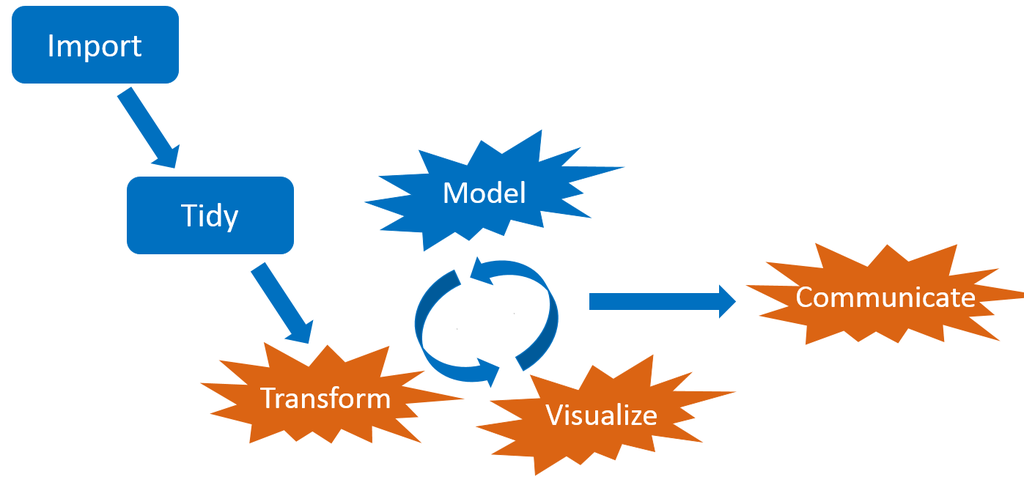

## Do you rerun **everything** from scratch?

- Takes too long.
- Too frustrating.

[figure not shown]

https://openclipart.org/detail/275842/sisyphus-overcoming-silhouette

## Do you manually hunt for pieces to update?

- Messy and prone to human error.
- Not reproducible.

[figure not shown]

https://openclipart.org/detail/216179/messy-desk

## Pipeline toolkits solve this problem.

- Sophisticated, vibrant, active space of tools: github.com/pditommaso/awesome-pipeline.
- Most are language-agnostic or designed for other languages.
- [**`drake`**](https://github.com/ropensci/drake) is uniquely devoted to R.
  - A focus on ordinary R functions and variables rather than cumbersome files.
  - Heavy use of the data frame, even as a substitute for the traditional [Makefile](https://www.gnu.org/software/make).
  - Native [tidy evaluation](https://tidyeval.tidyverse.org) support.
  - A [domain-specific language (DSL)](http://adv-r.had.co.nz/dsl.html) for [creating large workflows](https://ropenscilabs.github.io/drake-manual/plans.html#large-plans).

## Example uses in the pharmaceutical industry

- Clinical trial modeling and simulation
- Subgroup identification
- Bayesian network meta analysis
- Graph-based multiple comparison procedures
- Bayesian networks in genomics
- PK/PD modeling (e.g. [`mrgsolve`](https://github.com/metrumresearchgroup/mrgsolve))
- **Deep learning**

## Example deep learning workflow

- Goal: predict customers who cancel their subscriptions with a telecom company.
- Data: [IBM Watson Telco Customer Churn dataset](https://www.ibm.com/communities/analytics/watson-analytics-blog/predictive-insights-in-the-telco-customer-churn-data-set/).
- Workflow principles generalize to pharma, e.g. business analytics and genomics problems.

[figure not shown]

https://openclipart.org/detail/90739/newplus, https://github.com/rstudio/keras

## File structure

```
make.R
R/
├── packages.R
├── functions.R
└── plan.R
data/
└── customer_churn.csv
```

## `packages.R`

```r
# packages.R
library(drake)
library(keras)
library(recipes)
library(rsample)
library(tidyverse)
library(yardstick)
```

## `functions.R`

```r
# functions.R
prepare_recipe <- function(data) {
  # ...
}

define_model <- function(churn_recipe) {
  # ...
}

fit_model <- function(data, churn_recipe, model_file) {
  # ...
}

get_conf_matrix <- function(data, churn_recipe, model_file) {
  # ...
}
```

## `plan.R`

```r
# plan.R
plan <- drake_plan(
  data = read_csv(file_in("data/customer_churn.csv"), col_types = cols()) %>%
    initial_split(prop = 0.3),
  churn_recipe = prepare_recipe(data),
  history = fit_model(data, churn_recipe, file_out("model.h5")),
  history_plot = plot(history),
  conf_matrix = get_conf_matrix(data, churn_recipe, file_in("model.h5")),
  report_step = rmarkdown::render(
    knitr_in("results.Rmd"),
    output_file = file_out("results.html"),
    quiet = TRUE
  )
)
```

## The plan is a data frame.

```r
plan
## # A tibble: 6 x 2
##   target      command
##   <chr>       <expr>
## 1 data        read_csv(file_in("data/customer_churn.csv"), col_types = col…
## 2 churn_reci… prepare_recipe(data)                                        …
## 3 history     fit_model(data, churn_recipe, file_out("model.h5"))         …
## 4 history_pl… plot(history)                                               …
## 5 conf_matrix get_conf_matrix(data, churn_recipe, file_in("model.h5"))    …
## 6 report_step rmarkdown::render(knitr_in("results.Rmd"), output_file = fil…
```

## The workflow

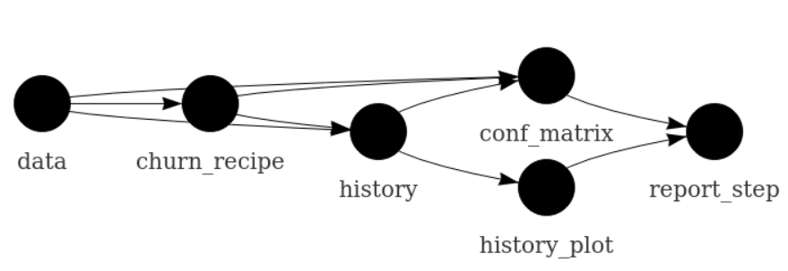

## Run the project in `make.R`

```r
# make.R
source("R/packages.R")
source("R/functions.R")
source("R/plan.R")

make(plan)
## target data
## target churn_recipe
## target history
## target conf_matrix
## target history_plot
## target report_step
```

## Inspect the results.

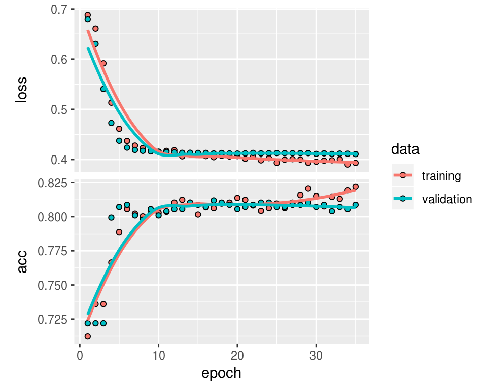

```r
readd(history_plot) # See also loadd()
```

## Update the plan.

```r
# plan.R
plan <- drake_plan(
  data = read_csv(file_in("data/customer_churn.csv"), col_types = cols()) %>%
    initial_split(prop = 0.3),
  churn_recipe = prepare_recipe(data),
  history = fit_model(data, churn_recipe, file_out("model.h5")),
  history_plot = plot(history) +
    theme_bw(), # modification
  conf_matrix = get_conf_matrix(data, churn_recipe, file_in("model.h5")),
  report_step = rmarkdown::render(
    knitr_in("results.Rmd"),
    output_file = file_out("results.html"),
    quiet = TRUE
  )
)
```

## `vis_drake_graph()`

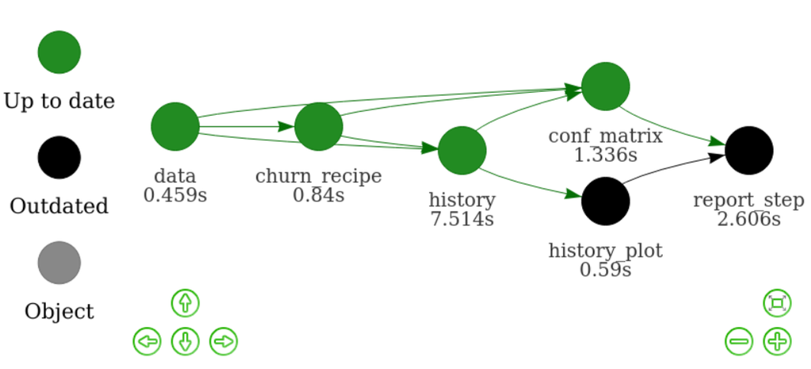

## Refresh the results.

```r
# make.R
source("R/packages.R")
source("R/functions.R")
source("R/plan.R") # modified

make(plan)
## target history_plot
## target report_step
```

## See updated results.

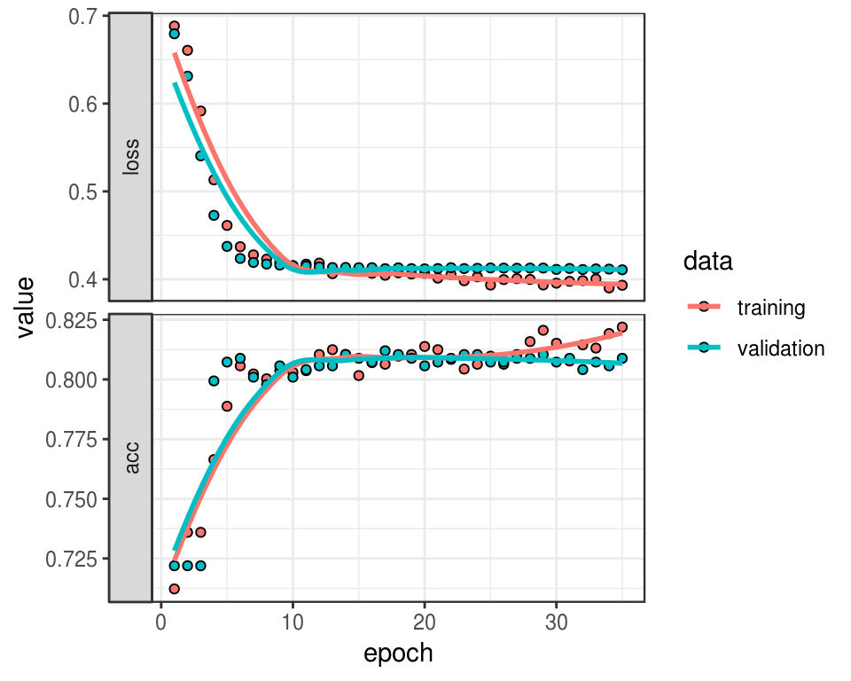

```r
readd(history_plot)
```

## Continue iterating to improve the model…

```r
readd(conf_matrix)
##           Truth
## Prediction   no  yes
##        no  3214  596
##        yes  405  707
```

## Evidence of reproducibility.

```r
# make.R
source("R/packages.R")
source("R/functions.R")
source("R/plan.R")

make(plan)
## All targets are already up to date.
```

- See also `outdated()`.

## Scale up the number of models.

```r
dataset_index <- seq_len(50)
plan <- drake_plan(
  data = target(
    download_dataset(source),
    transform = map(source = !!dataset_index)
  ),
  history = target(
    fit_my_model(data, learning_rate = lr),
    transform = cross(data, lr = c(1e-5, 1e-4, 1e-3))
  ),
  best = target(
    get_best_model(history),
    transform = combine(history)
  )
)
```

## Scale up the number of models.

```r
plan
## # A tibble: 201 x 2
##    target   command
##    <chr>    <expr>
##  1 data_1L  download_dataset(1L)
##  2 data_2L  download_dataset(2L)
##  3 data_3L  download_dataset(3L)
##  4 data_4L  download_dataset(4L)
##  5 data_5L  download_dataset(5L)
##  6 data_6L  download_dataset(6L)
##  7 data_7L  download_dataset(7L)
##  8 data_8L  download_dataset(8L)
##  9 data_9L  download_dataset(9L)
## 10 data_10L download_dataset(10L)
## # … with 191 more rows
```

## `drake_ggraph()` for large graphs

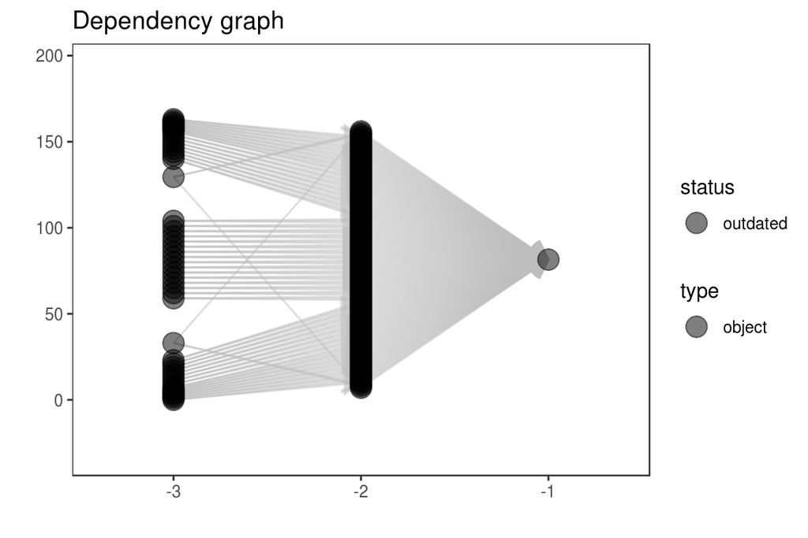

## High-performance computing.

```r
# make.R

# template file with configuration
drake_hpc_template_file("slurm_clustermq.tmpl")

# Use SLURM resource manager with the template.
options(
  clustermq.scheduler = "slurm",
  clustermq.template = "slurm_clustermq.tmpl"
)

# make() is the basically the same.
make(plan, jobs = 2, parallelism = "clustermq")
```

## High-performance computing.

[figure not shown]

## Resources

```r
install.packages("drake")                  # release
devtools::install_github("ropensci/drake") # development
```

- [Today’s code](https://github.com/wlandau/drake-examples/tree/master/deep-learning): `drake_example("deep-learning")`
- [Reference website](https://ropensci.github.io/drake/)
- [Full user manual](https://ropenscilabs.github.io/drake-manual/)
- [Example workflows](https://github.com/wlandau/drake-examples)
- [File an issue](https://github.com/ropensci/drake/issues).
- [Contribute code](https://github.com/ropensci/drake/pulls).
- [Discuss at rOpenSci.org](https://discuss.ropensci.org).

## Today’s example

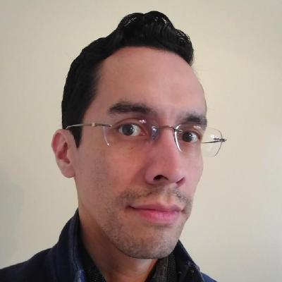

- [Edgar Ruiz](https://github.com/edgararuiz)
- [example code](https://github.com/sol-eng/tensorflow-w-r/blob/master/workflow/tensorflow-drake.Rmd)

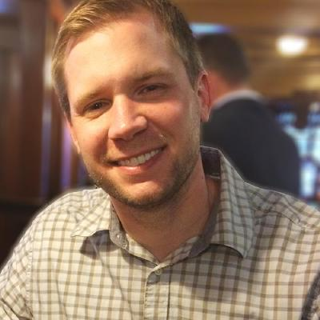

- [Matt Dancho](https://github.com/mdancho84)
- [blog post](https://blogs.rstudio.com/tensorflow/posts/2018-01-11-keras-customer-churn/)

## Development

[figure not shown]

- [Maëlle Salmon](https://github.com/maelle)
- [Ben Marwick](https://github.com/benmarwick)
- [Julia Lowndes](https://github.com/jules32)
- [Peter Slaughter](https://github.com/gothub)
- [Jenny Bryan](https://github.com/jennybc)
- [Rich FitzJohn](https://github.com/richfitz)
- [Stefanie Butland](https://github.com/stefaniebutland)
- [Jarad Niemi](https://github.com/jarad)
- [Kirill Müller](https://github.com/krlmlr)
- [Henrik Bengtsson](https://github.com/HenrikBengtsson)
- [Miles McBain](https://github.com/milesmcbain)
- [Patrick Schratz](https://github.com/pat-s)
- [Kendon Bell](https://github.com/kendonB)
- [Alex Axthelm](https://github.com/AlexAxthelm)
- [Jasper Clarkberg](https://github.com/dapperjapper)
- [Daniel Falster](https://github.com/dfalster)
- [Chan-Yub Park](https://github.com/mrchypark)
- [Tiernan Martin](https://github.com/tiernanmartin)